# Predicting Grain Crop Yields in India for Years 1997 - 2020

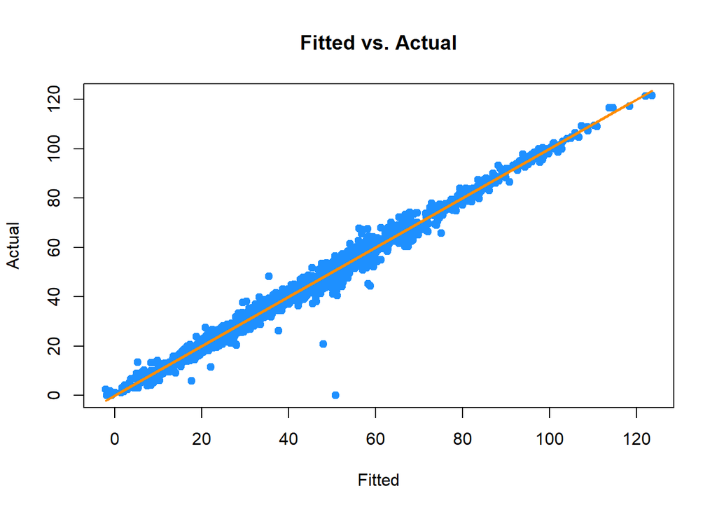

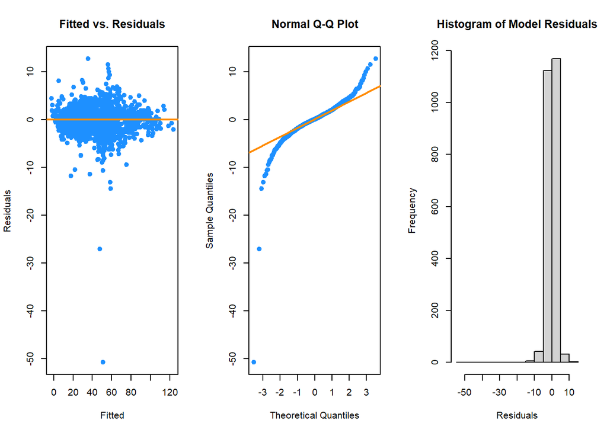

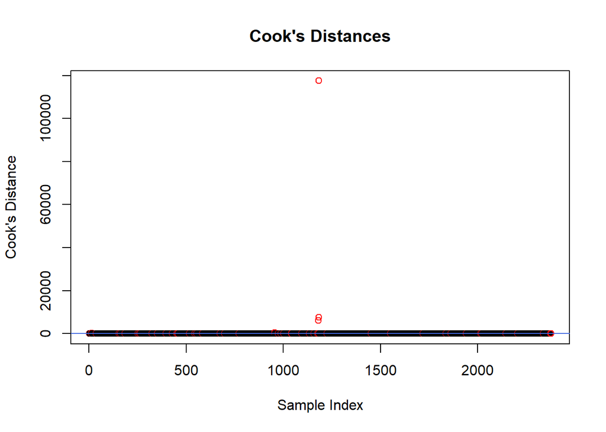

```
## [1] "LOOCV-RMSE:"      "348.953671702553"
```

```r
multi.full.bc.cropyear_cont <- lm(
  paste(
    "bc_transform(Production, multi.full.bc.cropyear_cont_lambda) ~ ",
    paste(
      attr(terms(multi.form.cropyear_cont),
        which = "term.labels"
      ),
      collapse = " + "
    )
  ),
  data = crops.train.multi.no_infl
)
output_diagnostics(multi.full.bc.cropyear_cont, vif = FALSE)
```

We also want to evaluate whether our models can be made simpler, so we do variable selection using forward BIC on them.

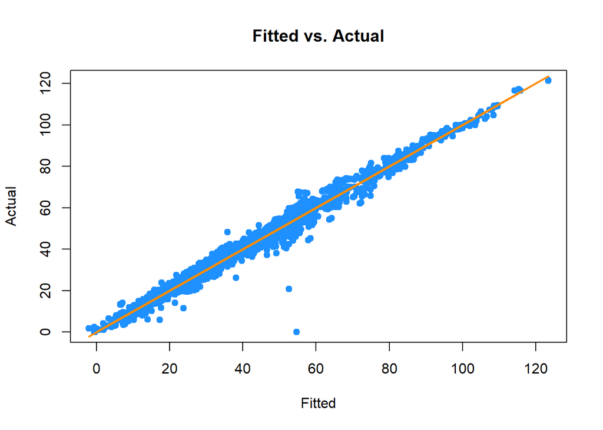

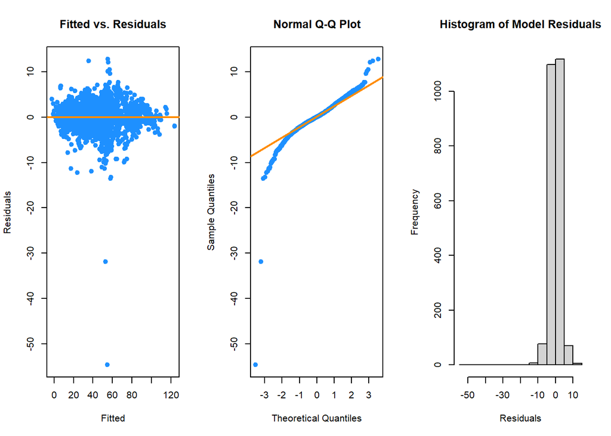

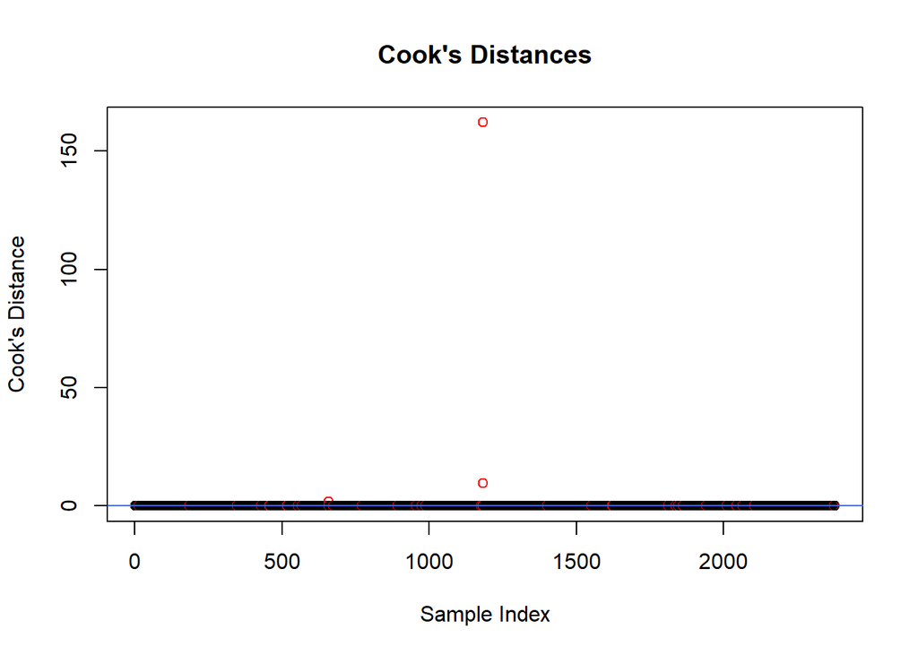

```
## [1] "LOOCV-RMSE:"      "8.27198566623824"
```

```r
multi.bic.forward.bc.cropyear_cont <- step(lm(bc_transform(Production, multi.full.bc.cropyear_cont_lambda) ~ 1, data = crops.train.multi.no_infl),
  scope = as.formula(
    paste(
      "bc_transform(Production, multi.full.bc.cropyear_cont_lambda) ~ ",
      paste(
        attr(terms(multi.form.cropyear_cont),
          which = "term.labels"
        ),
        collapse = " + "
      )
    )
  ),
  direction = "forward", trace = 0,
  k = log(nrow(crops.train.multi.no_infl))
)
output_diagnostics(multi.bic.forward.bc.cropyear_cont, vif = 0)
```

As mentioned above, one point of interest as we explored our models was whether crop year was better as a continuous or categorical variable. Below we perform a set of similar tests, only with crop year as a category.

```r
vars.res <- "Production"
vars.con <- c("Area", "Annual_Rainfall", "Fertilizer", "Pesticide")
vars.cat <- c("Crop", "Season", "Zone", "Crop_Year")
```

```r
crops$Crop_Year <- as.factor(crops$Crop_Year)
```

```r
# Train-test split
set.seed(0)

sample <- sample(c(TRUE, FALSE), nrow(crops), replace = TRUE, prob = c(0.8, 0.2))
crops.train <- crops[sample, ]
crops.test.cropyear_cat <- crops[!sample, ]

nrow(crops)
```

```
## [1] 3160
```

```r
nrow(crops.train)
```

```
## [1] 2522
```

```r
nrow(crops.test.cropyear_cat)
```

```
## [1] 638
```

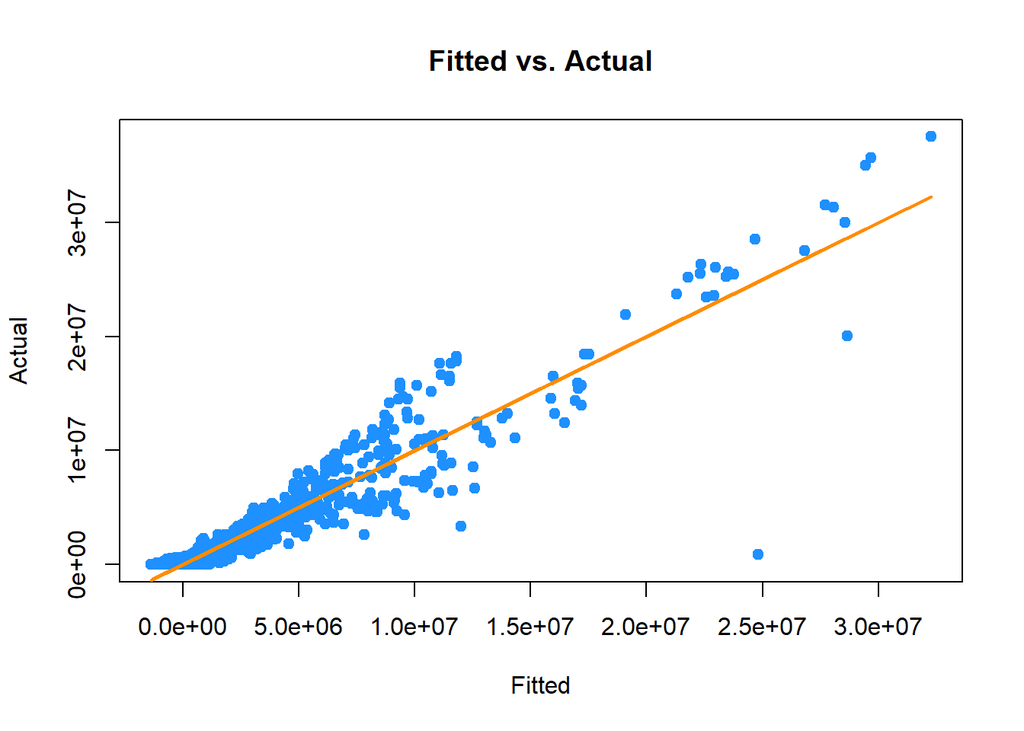

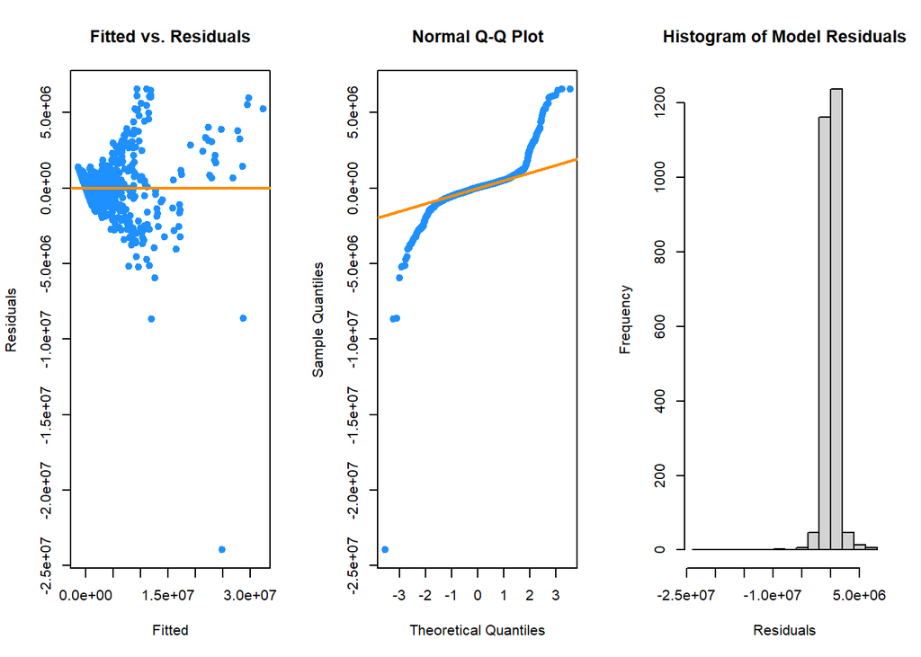

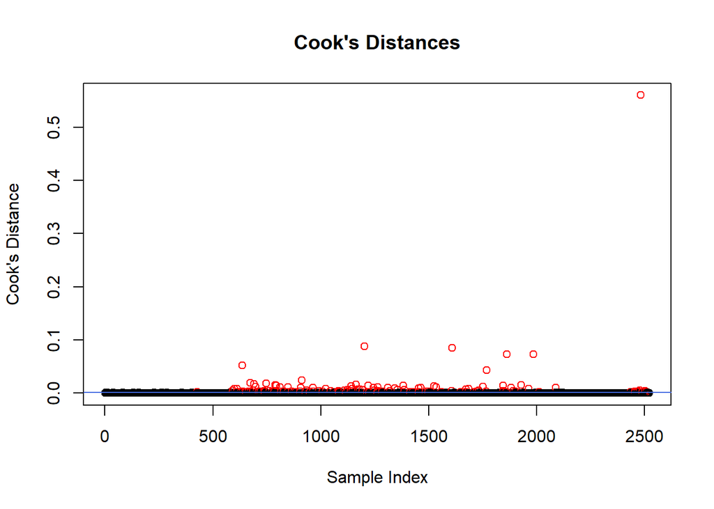

```
## [1] "LOOCV-RMSE:"      "1136746.85129321"
```

```
##                      GVIF Df GVIF^(1/(2*Df))
## Crop             3.200182  4        1.156503
## Crop_Year        1.645538 23        1.010886
## Season           3.680821  5        1.139186
## Zone             3.583287  5        1.136130
## Area            32.788601  1        5.726133
## Annual_Rainfall  1.957520  1        1.399114
## Fertilizer      31.603021  1        5.621656
## Pesticide       17.903422  1        4.231244
```

```r
baseline.cropyear_cat <- lm(Production ~ ., data = crops.train)
output_diagnostics(baseline.cropyear_cat)
```

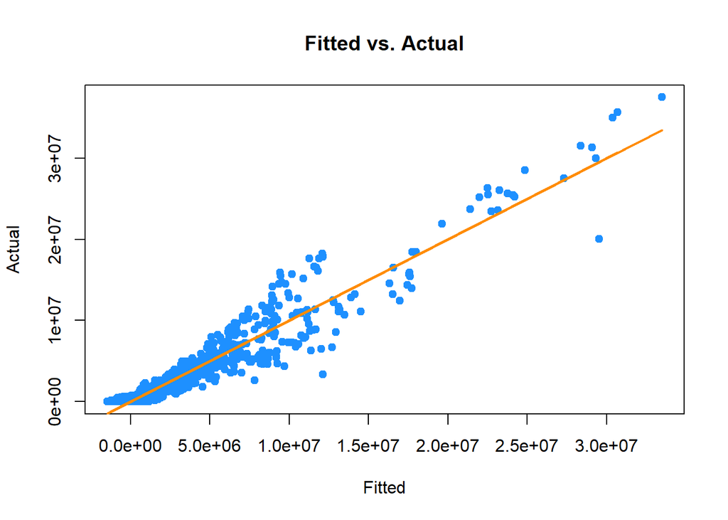

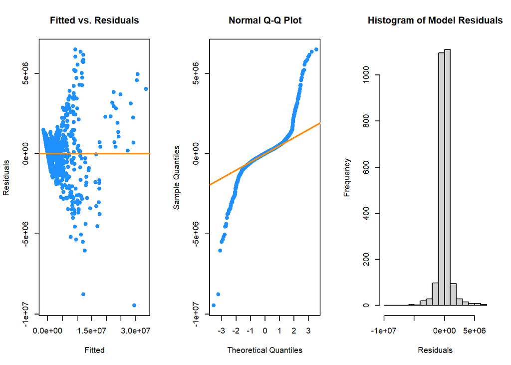

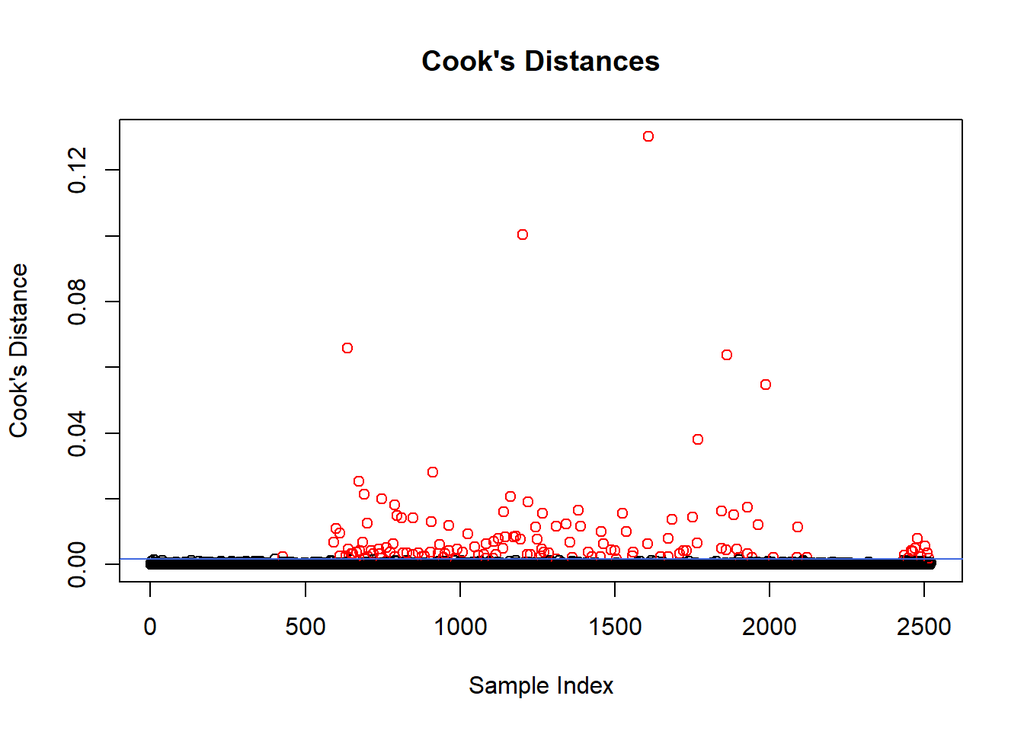

```
## [1] "LOOCV-RMSE:"      "1014437.27021745"
```

```
##                      GVIF Df GVIF^(1/(2*Df))
## Crop             3.208501  4        1.156879
## Crop_Year        1.646556 23        1.010900
## Season           3.701860  5        1.139835
## Zone             3.590927  5        1.136372
## Area            32.373118  1        5.689738
## Annual_Rainfall  1.959700  1        1.399893
## Fertilizer      31.092873  1        5.576098
## Pesticide       17.581416  1        4.193020
```

```r
idx_remove <- which.max(cooks.distance(baseline.cropyear_cat))
crops.train.no_infl <- crops.train[-idx_remove, ]

baseline.no_infl.cropyear_cat <- lm(Production ~ ., data = crops.train.no_infl)
output_diagnostics(baseline.no_infl.cropyear_cat)
```

```r
baseline.cropyear_cat <- lm(I(Production) ~ ., data = crops.train.no_infl)

bc <- boxcox(baseline.cropyear_cat)
```

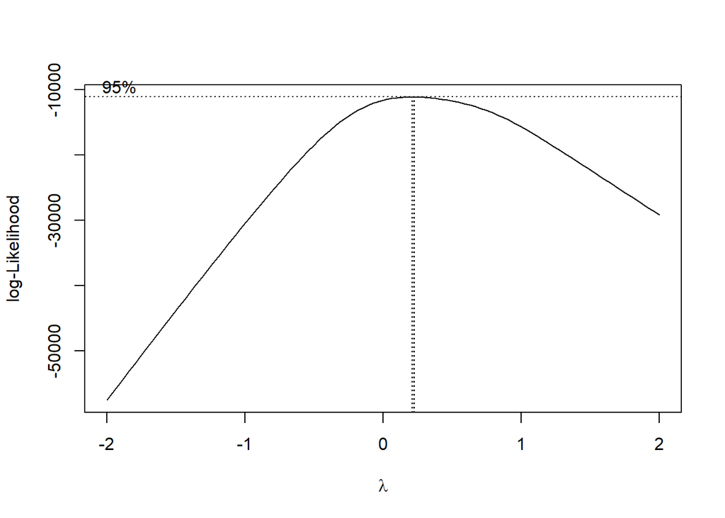

```r
(baseline.bc.cropyear_cat_lambda <- bc$x[which.max(bc$y)])
```

```
## [1] 0.2222222
```

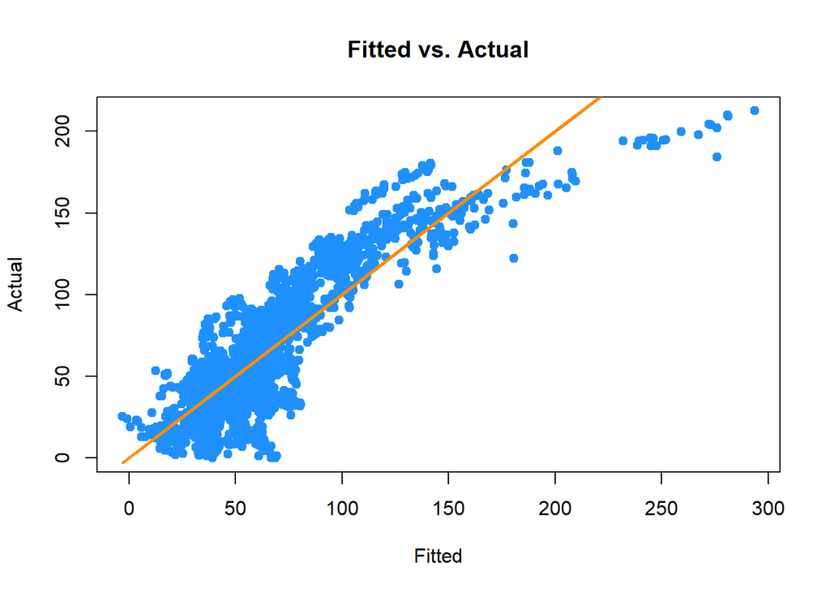

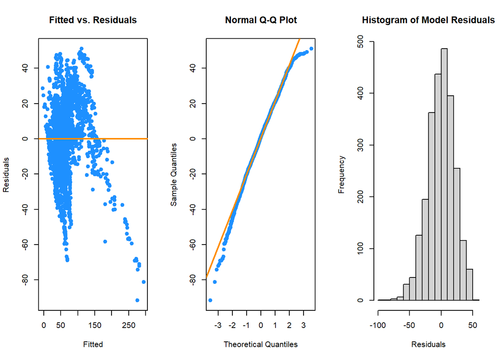

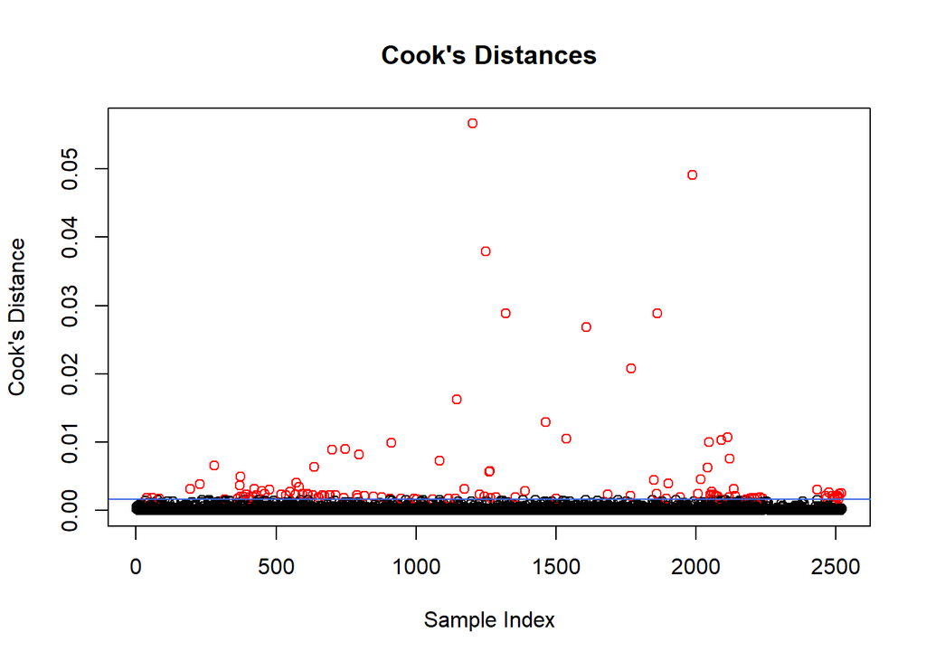

```
## [1] "LOOCV-RMSE:"      "21.5486350274448"
```

```
##                      GVIF Df GVIF^(1/(2*Df))
## Crop             3.208501  4        1.156879
## Crop_Year        1.646556 23        1.010900
## Season           3.701860  5        1.139835
## Zone             3.590927  5        1.136372
## Area            32.373118  1        5.689738
## Annual_Rainfall  1.959700  1        1.399893
## Fertilizer      31.092873  1        5.576098
## Pesticide       17.581416  1        4.193020
```

```r
baseline.bc.cropyear_cat <- lm(bc_transform(Production, baseline.bc.cropyear_cat_lambda) ~ ., data = crops.train.no_infl)
output_diagnostics(baseline.bc.cropyear_cat)
```

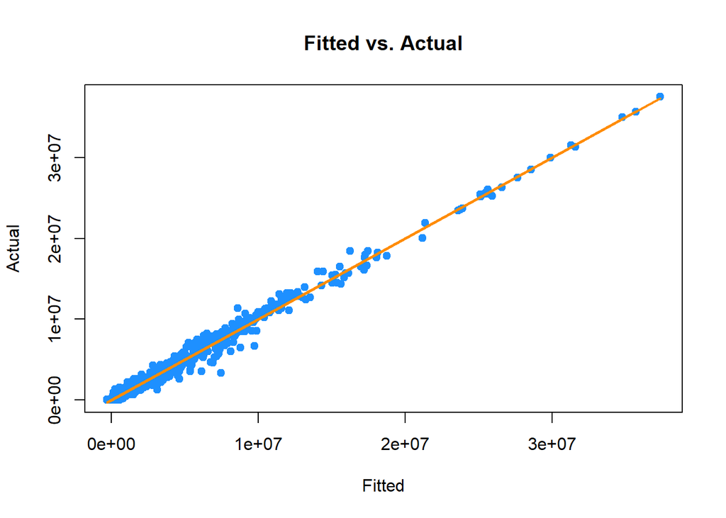

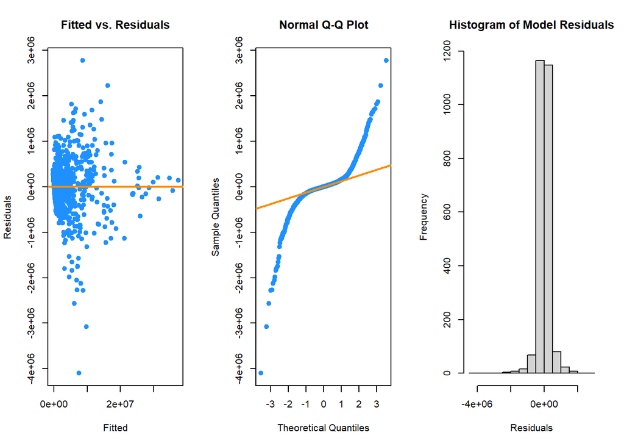

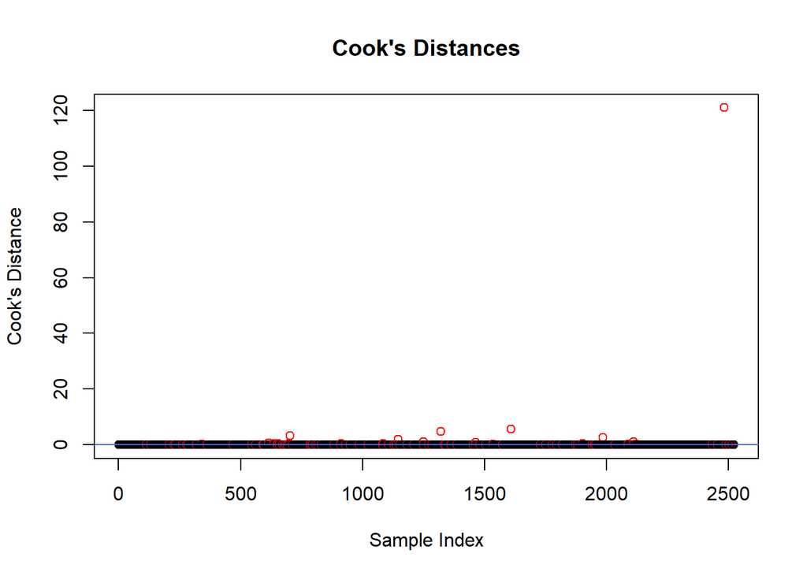

```
## [1] "LOOCV-RMSE:"      "1420135.72214569"
```

```r
# continuous-categorical interactions
baseline.poly.form.cropyear_cat <- as.formula(Production ~
  (poly(Area, degree = 2, raw = 1) +
    poly(Annual_Rainfall, degree = 2, raw = 1) +
    poly(Fertilizer, degree = 2, raw = 1) +
    poly(Pesticide, degree = 2, raw = 1)) *
    (Crop + Season + Zone + Crop_Year))
baseline.poly.cropyear_cat <- lm(baseline.poly.form.cropyear_cat, data = crops.train)
output_diagnostics(baseline.poly.cropyear_cat, vif = 0)
```

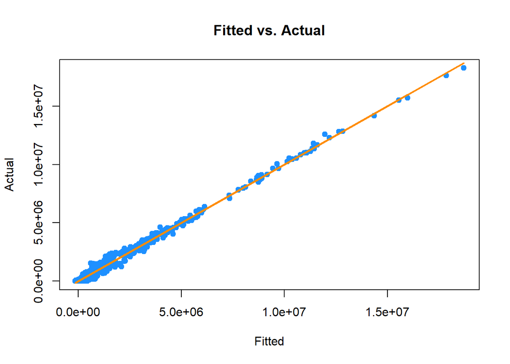

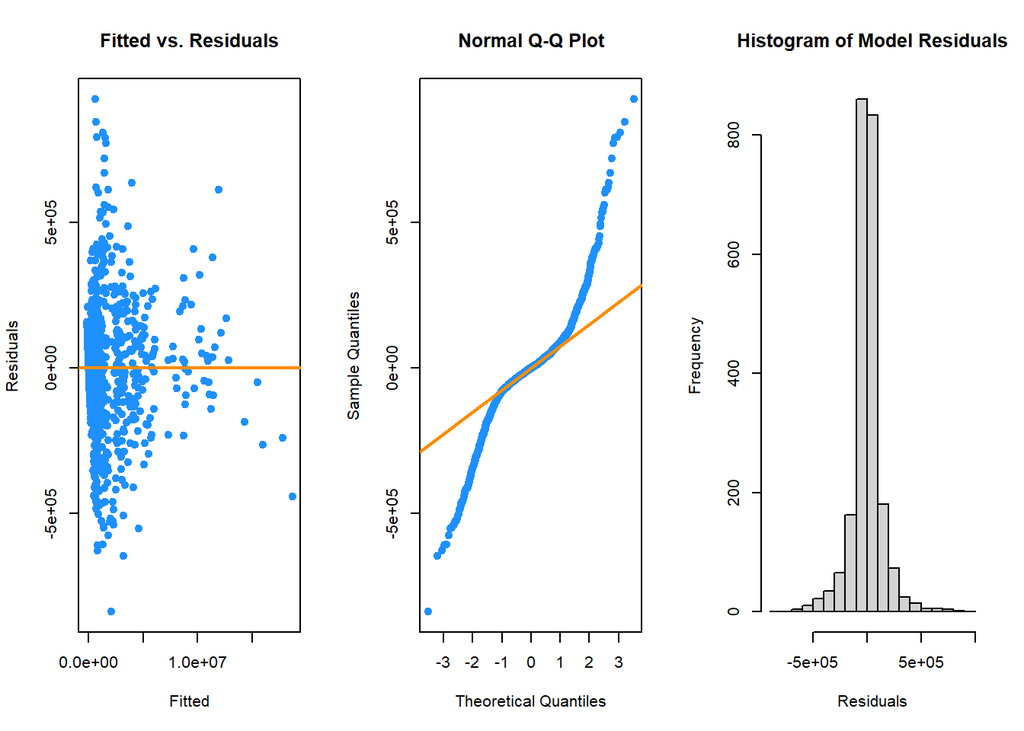

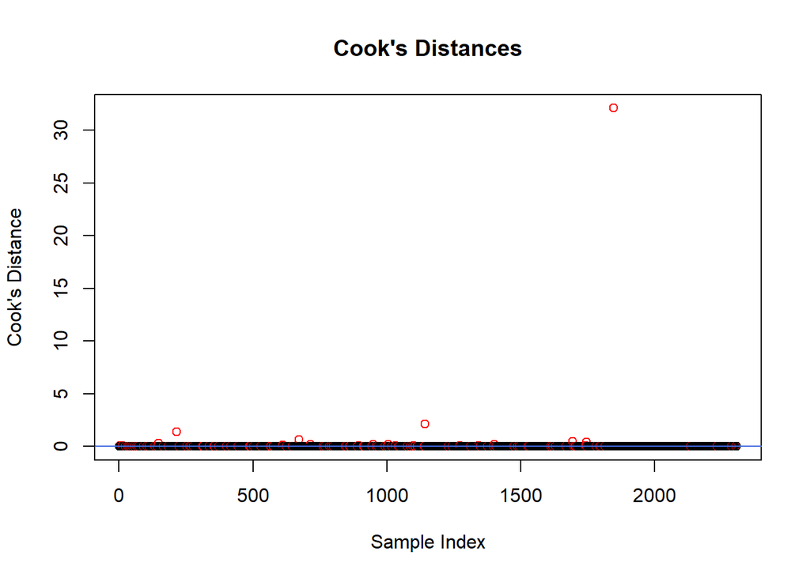

```
## [1] "LOOCV-RMSE:"      "351341.281426551"
```

```r
crops.train.poly.no_infl <- crops.train[!idx_infl_pts(baseline.poly.cropyear_cat), ]

baseline.poly.cropyear_cat <- lm(baseline.poly.form.cropyear_cat, data = crops.train.poly.no_infl)
output_diagnostics(baseline.poly.cropyear_cat, vif = 0)
```

```r
bc <- boxcox(baseline.poly.cropyear_cat)
```

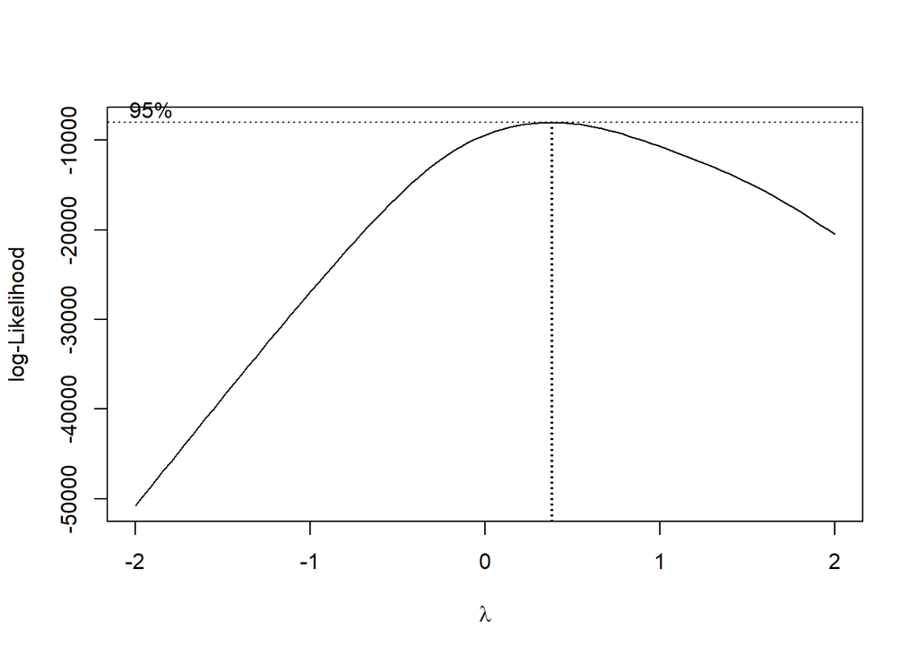

```r
(baseline.poly.bc.cropyear_cat_lambda <- bc$x[which.max(bc$y)])
```

```
## [1] 0.3838384
```

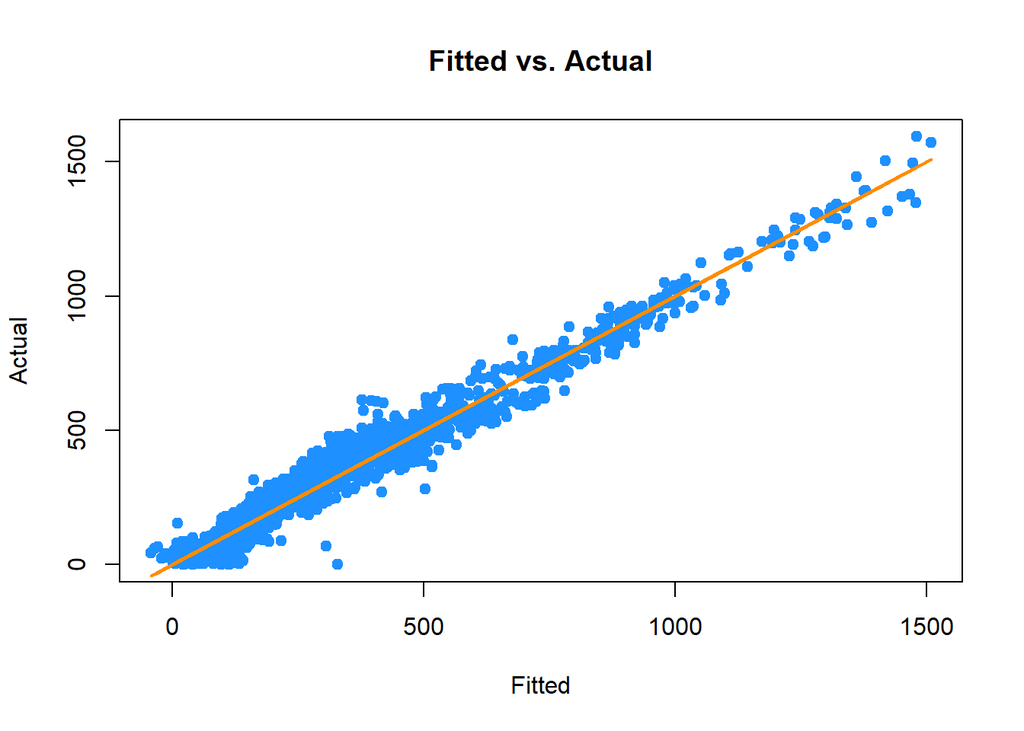

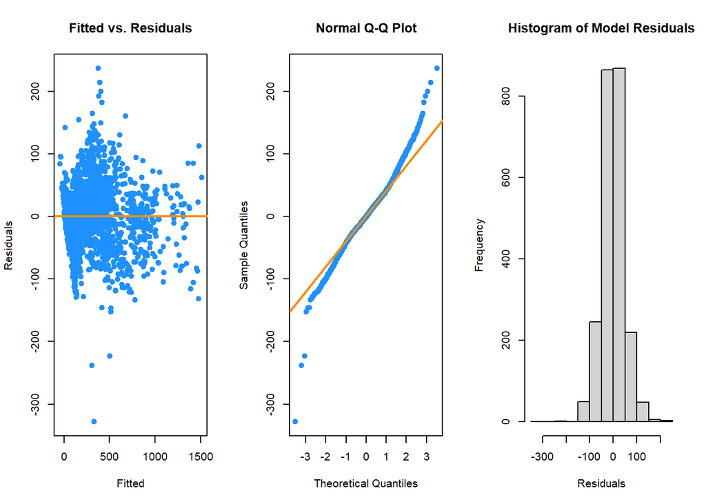

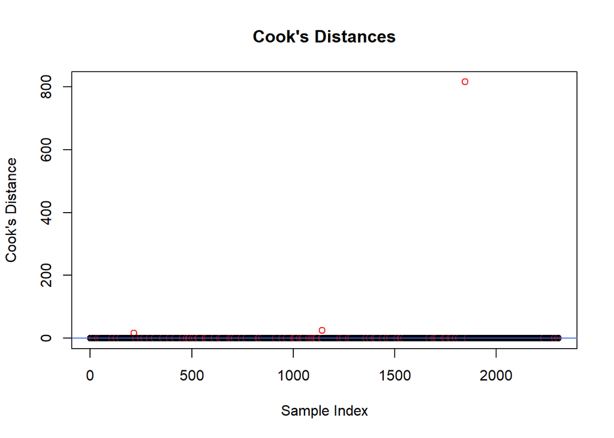

```
## [1] "LOOCV-RMSE:"      "488.505295185118"
```

```r
baseline.poly.bc.cropyear_cat <- lm(
  paste(
    "bc_transform(Production, baseline.poly.bc.cropyear_cat_lambda) ~ ",
    paste(
      attr(terms(baseline.poly.form.cropyear_cat),
        which = "term.labels"
      ),
      collapse = " + "
    )
  ),
  data = crops.train.poly.no_infl
)
output_diagnostics(baseline.poly.bc.cropyear_cat, vif = 0)
```

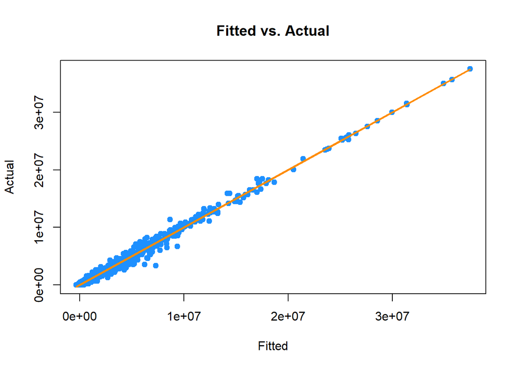

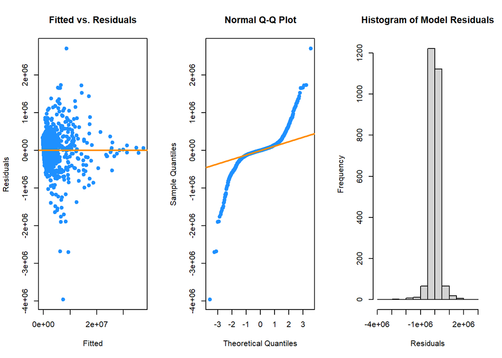

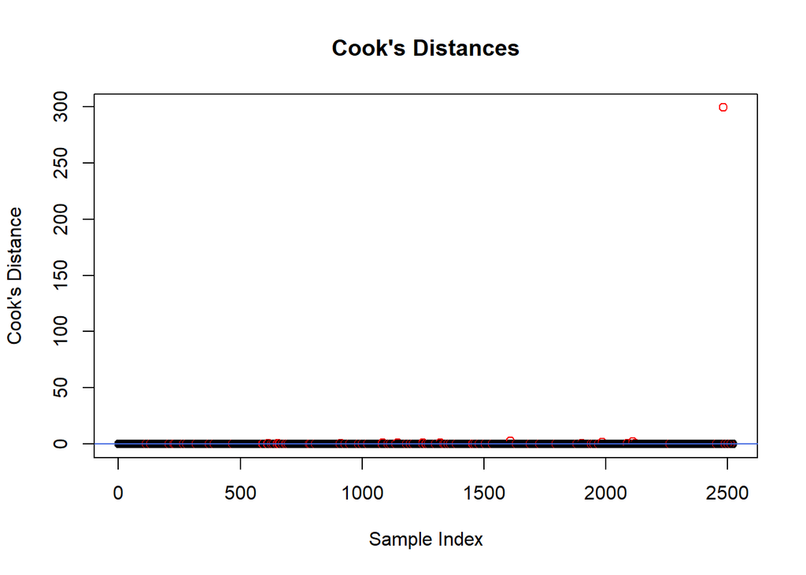

```
## [1] "LOOCV-RMSE:"      "2551303.70077557"
```

```r
multi.form.cropyear_cat <- as.formula(Production ~
  (poly(Area, degree = 2, raw = 1) +
    poly(Annual_Rainfall, degree = 2, raw = 1) +
    poly(Fertilizer, degree = 2, raw = 1) +
    poly(Pesticide, degree = 2, raw = 1) +
    I(sqrt(Area)) +
    I(sqrt(Annual_Rainfall)) +
    I(sqrt(Fertilizer)) +
    I(sqrt(Pesticide)) +
    I(log(Area)) +
    I(log(Annual_Rainfall)) +
    I(log(Fertilizer)) +
    I(log(Pesticide))) *
    (Crop + Season + Zone + Crop_Year))
multi.full.cropyear_cat <- lm(multi.form.cropyear_cat, data = crops.train)
output_diagnostics(multi.full.cropyear_cat, vif = FALSE)
```

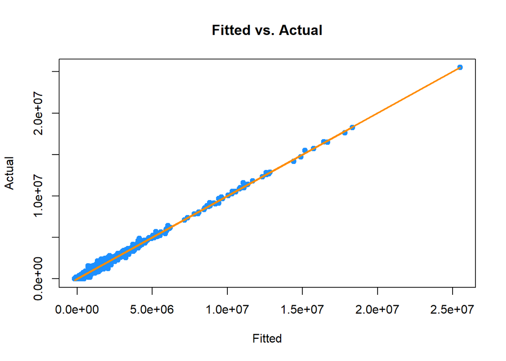

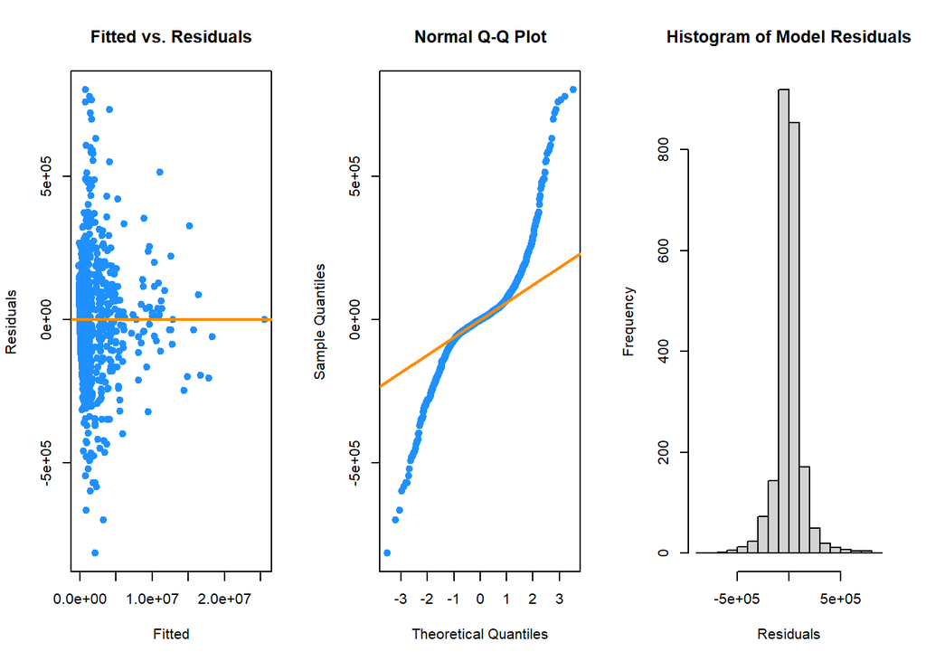

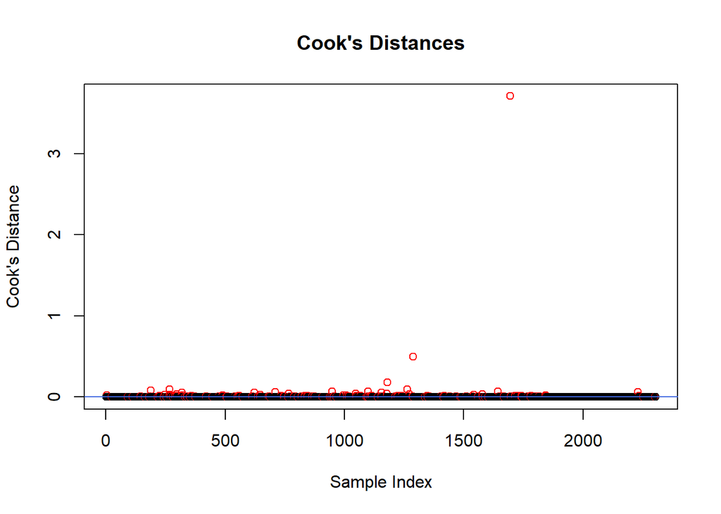

```
## [1] "LOOCV-RMSE:" "Inf"
```

```r
crops.train.multi.no_infl <- crops.train[!idx_infl_pts(multi.full.cropyear_cat), ]

multi.full.cropyear_cat <- lm(multi.form.cropyear_cat, data = crops.train.multi.no_infl)
output_diagnostics(multi.full.cropyear_cat, vif = FALSE)
```

```r
bc <- boxcox(multi.full.cropyear_cat)
```

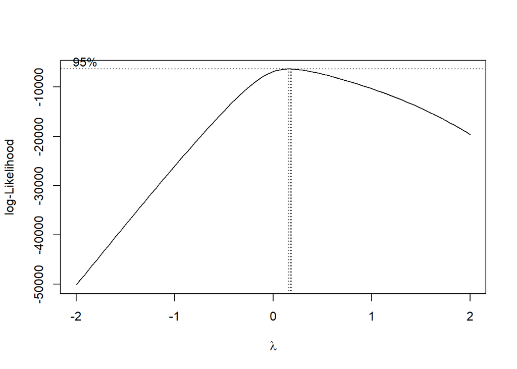

```r
(multi.full.bc.cropyear_cat_lambda <- bc$x[which.max(bc$y)])
```

```
## [1] 0.1818182
```

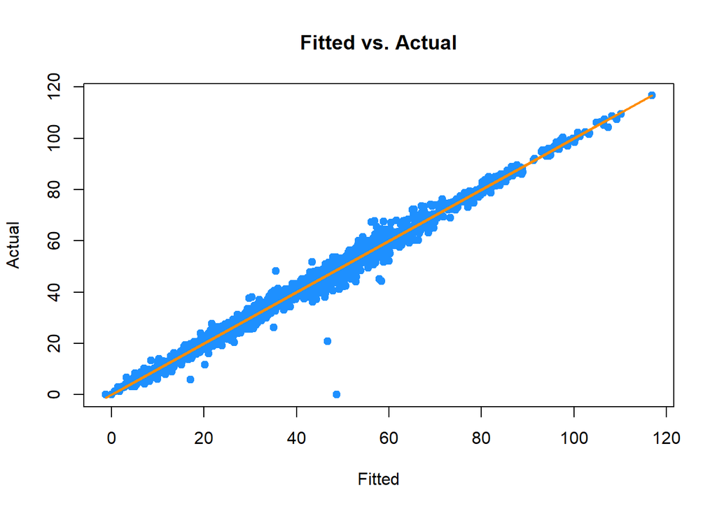

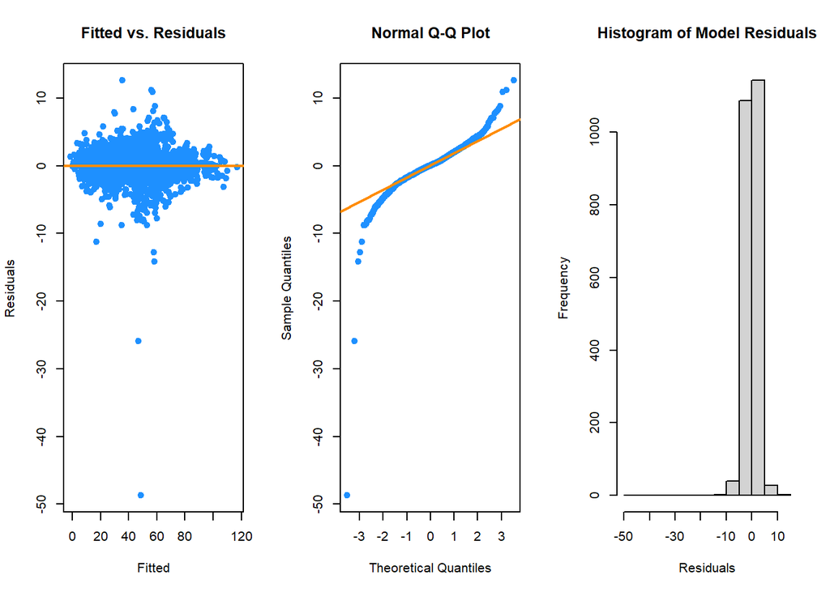

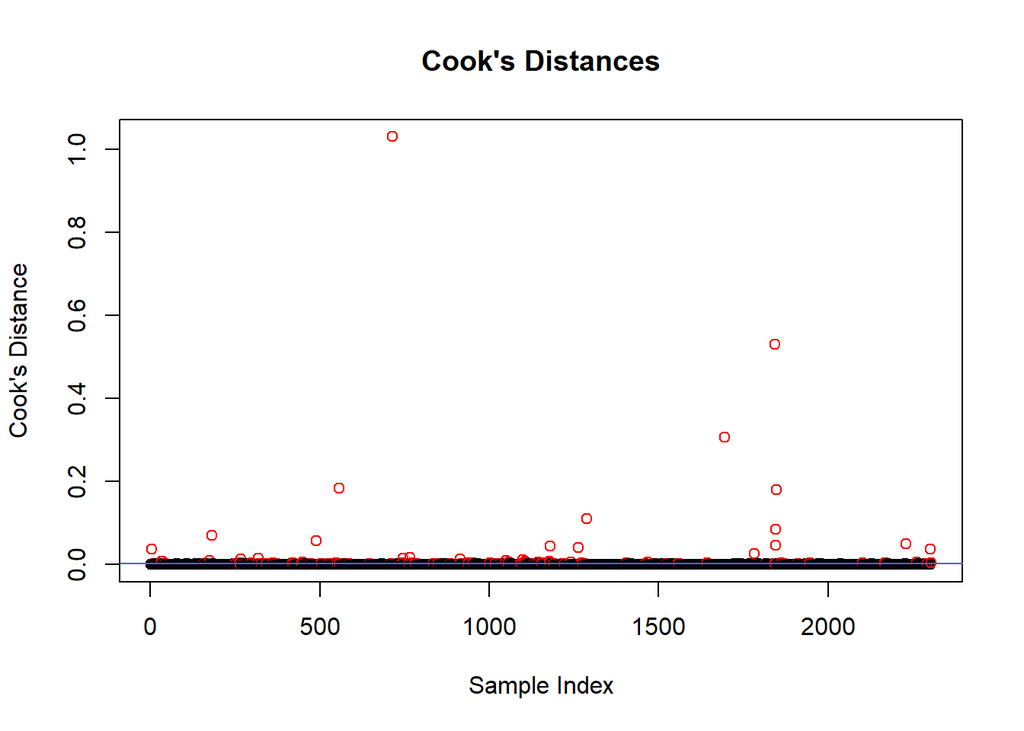

```
## [1] "LOOCV-RMSE:" "Inf"
```

```r
multi.full.bc.cropyear_cat <- lm(
  paste(
    "bc_transform(Production, multi.full.bc.cropyear_cat_lambda) ~ ",
    paste(
      attr(terms(multi.form.cropyear_cat),
        which = "term.labels"
      ),
      collapse = " + "
    )
  ),
  data = crops.train.multi.no_infl
)
output_diagnostics(multi.full.bc.cropyear_cat, vif = FALSE)
```

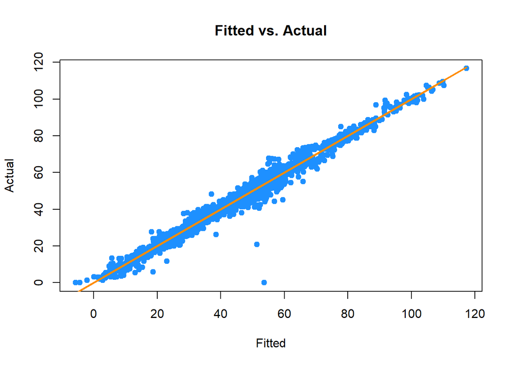

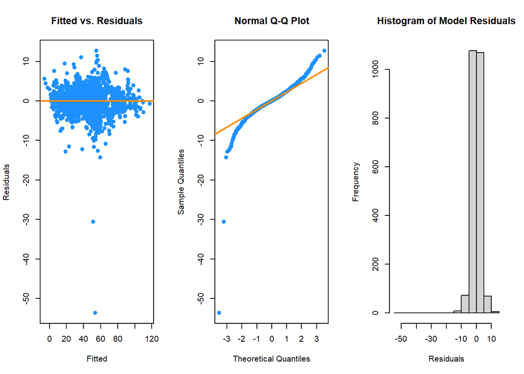

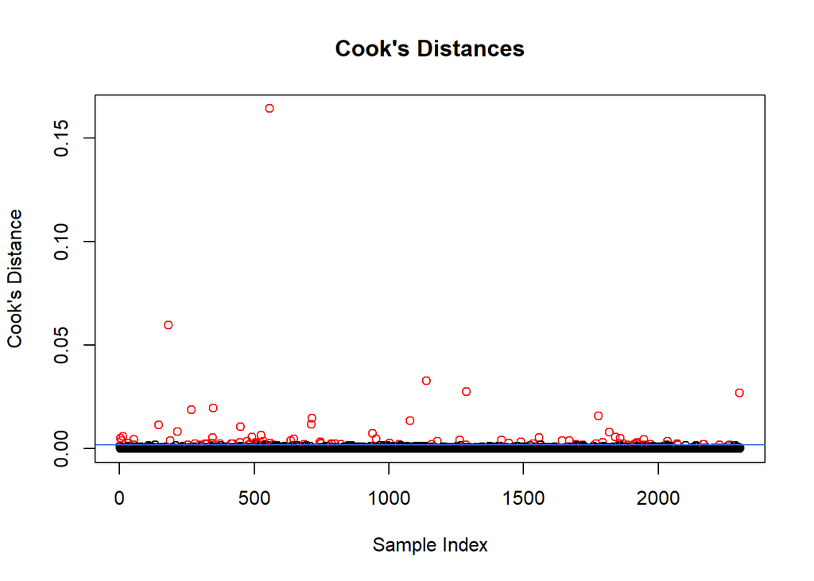

```
## [1] "LOOCV-RMSE:"      "3.07261268811736"
```

```r
multi.bic.forward.bc.cropyear_cat <- step(lm(bc_transform(Production, multi.full.bc.cropyear_cat_lambda) ~ 1, data = crops.train.multi.no_infl),
  scope = as.formula(
    paste(
      "bc_transform(Production, multi.full.bc.cropyear_cat_lambda) ~ ",
      paste(
        attr(terms(multi.form.cropyear_cat),
          which = "term.labels"
        ),
        collapse = " + "
      )
    )
  ),
  direction = "forward", trace = 0,
  k = log(nrow(crops.train.multi.no_infl))
)
output_diagnostics(multi.bic.forward.bc.cropyear_cat, vif = 0)
```

The next iteration of our crop year experiment was to leave the potential predictor out entirely. We then proceed to run the similar set of evaluations one more time.

```r
vars.res <- "Production"
vars.con <- c("Area", "Annual_Rainfall", "Fertilizer", "Pesticide")
vars.cat <- c("Crop", "Season", "Zone")
```

```r
# Train-test split
set.seed(0)

sample <- sample(c(TRUE, FALSE), nrow(crops), replace = TRUE, prob = c(0.8, 0.2))
crops.train <- crops[sample, ]
crops.test.cropyear_omit <- crops[!sample, ]

crops.train <- crops.train[, !(names(crops.train) %in% c("Crop_Year"))]
crops.test.cropyear_omit <- crops.test.cropyear_omit[, !(names(crops.test.cropyear_omit) %in% c("Crop_Year"))]

nrow(crops)
```

```
## [1] 3160
```

```r
nrow(crops.train)
```

```
## [1] 2522
```

```r
nrow(crops.test.cropyear_omit)
```

```
## [1] 638
```

```r
baseline.cropyear_omit <- lm(Production ~ ., data = crops.train)
output_diagnostics(baseline.cropyear_omit)
```

```
## [1] "Model Summary:"
##
## Call:
## lm(formula = Production ~ ., data = crops.train)
##
## Residuals:
##       Min        1Q    Median        3Q       Max
## -24076792   -335350     20743    327629   6728077
##
## Coefficients:
##                     Estimate Std. Error t value Pr(>|t|)
## (Intercept)        8.079e+04  1.595e+05   0.507 0.612500
## CropMaize          3.150e+05  9.551e+04   3.298 0.000988 ***
## CropOther Cereals  2.883e+05  1.325e+05   2.176 0.029628 *
## CropRice          -2.844e+04  1.018e+05  -0.279 0.779945
## CropWheat          2.908e+05  9.553e+04   3.044 0.002360 **
## SeasonKharif      -3.036e+05  1.034e+05  -2.936 0.003354 **
## SeasonRabi         1.660e+05  1.112e+05   1.492 0.135704
## SeasonSummer       2.544e+05  1.085e+05   2.343 0.019191 *
## SeasonWhole Year  -4.357e+05  2.497e+05  -1.745 0.081188 .
## SeasonWinter      -9.624e+05  1.294e+05  -7.439 1.39e-13 ***
## ZoneNorth Eastern -2.769e+05  8.056e+04  -3.437 0.000598 ***
## ZoneEastern       -6.613e+05  8.298e+04  -7.970 2.40e-15 ***
## ZoneCentral       -8.434e+05  8.408e+04 -10.031  < 2e-16 ***
## ZoneNorthern       4.123e+05  8.687e+04   4.747 2.18e-06 ***
## ZoneWestern       -5.763e+05  8.886e+04  -6.486 1.06e-10 ***
## Area               1.228e+00  9.166e-02  13.393  < 2e-16 ***
## Annual_Rainfall    2.308e+01  3.600e+01   0.641 0.521521
## Fertilizer         9.000e-03  6.536e-04  13.771  < 2e-16 ***
## Pesticide          1.107e+00  2.417e-01   4.580 4.87e-06 ***
## ---
## Signif. codes:  0 '***' 0.001 '**' 0.01 '*' 0.05 '.' 0.1 ' ' 1
##
## Residual standard error: 1111000 on 2503 degrees of freedom
## Multiple R-squared:  0.9027, Adjusted R-squared:  0.902
## F-statistic:  1290 on 18 and 2503 DF,  p-value: < 2.2e-16
```

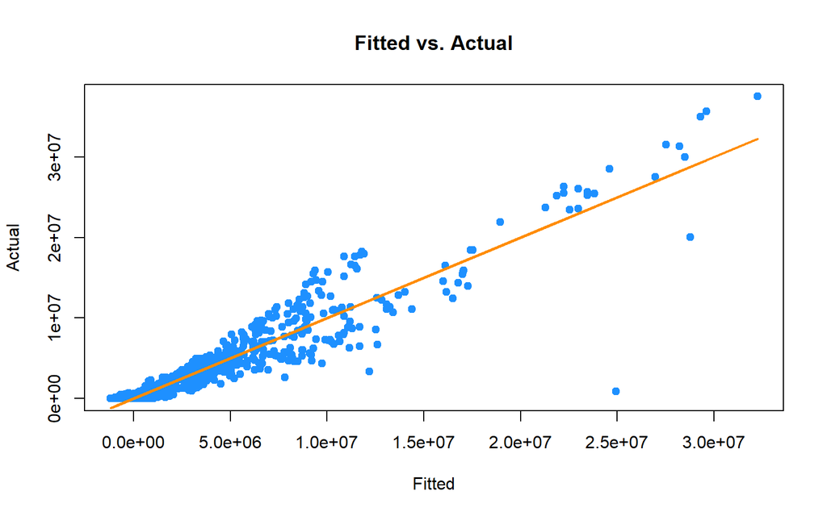

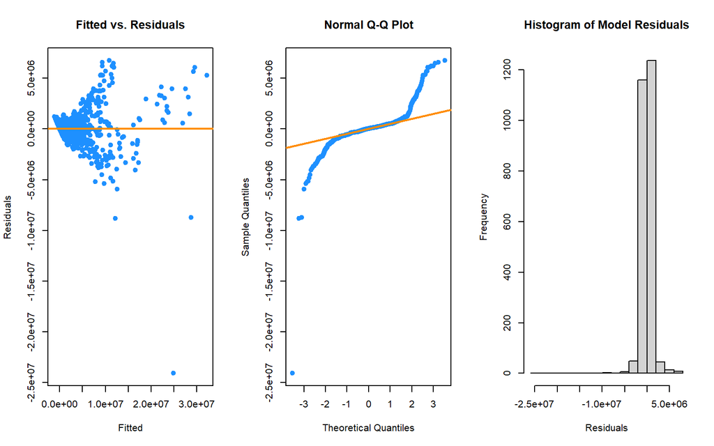

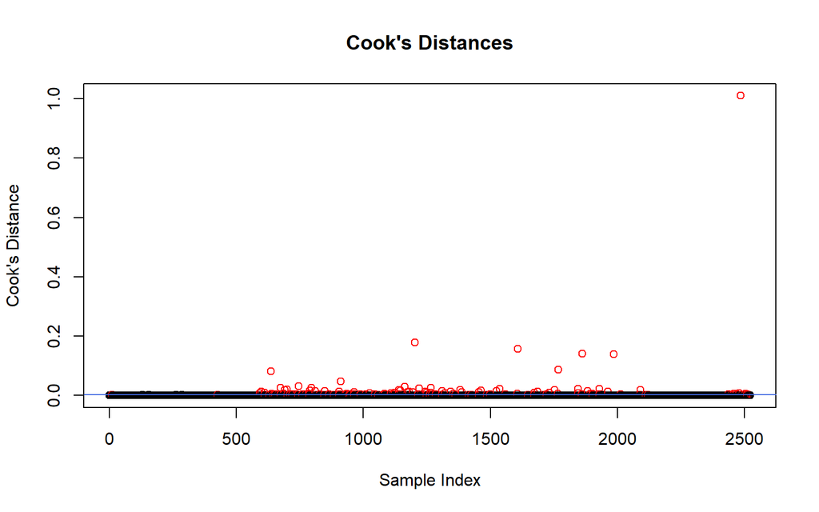

```
## [1] "LOOCV-RMSE:"      "1131262.79650772"
```

```
##                      GVIF Df GVIF^(1/(2*Df))
## Crop             3.110167  4        1.152386
## Season           3.520615  5        1.134127
## Zone             3.406343  5        1.130391
## Area            27.555842  1        5.249366
## Annual_Rainfall  1.897992  1        1.377676
## Fertilizer      26.161104  1        5.114793
## Pesticide       15.043902  1        3.878647
```

```r
idx_remove <- which.max(cooks.distance(baseline.cropyear_omit))
crops.train.no_infl <- crops.train[-idx_remove, ]

baseline.no_infl.cropyear_omit <- lm(Production ~ ., data = crops.train.no_infl)
output_diagnostics(baseline.no_infl.cropyear_omit)
```

```
## [1] "Model Summary:"
##
## Call:
## lm(formula = Production ~ ., data = crops.train.no_infl)
##
## Residuals:
##      Min       1Q   Median       3Q      Max
## -9560434  -343979    18095   323999  6527899
##
## Coefficients:
##                     Estimate Std. Error t value Pr(>|t|)
## (Intercept)        3.272e+04  1.431e+05   0.229 0.819212
## CropMaize          2.911e+05  8.572e+04   3.396 0.000695 ***
## CropOther Cereals  3.050e+05  1.189e+05   2.565 0.010364 *
## CropRice          -7.492e+04  9.136e+04  -0.820 0.412274
## CropWheat          1.934e+05  8.582e+04   2.253 0.024319 *
## SeasonKharif      -2.972e+05  9.280e+04  -3.202 0.001380 **
## SeasonRabi         1.944e+05  9.983e+04   1.947 0.051667 .
## SeasonSummer       3.743e+05  9.753e+04   3.837 0.000127 ***
## SeasonWhole Year  -4.164e+05  2.241e+05  -1.858 0.063283 .
## SeasonWinter      -1.067e+06  1.162e+05  -9.187  < 2e-16 ***
## ZoneNorth Eastern -2.578e+05  7.229e+04  -3.566 0.000369 ***
## ZoneEastern       -6.185e+05  7.449e+04  -8.304  < 2e-16 ***
## ZoneCentral       -9.119e+05  7.550e+04 -12.077  < 2e-16 ***
## ZoneNorthern       4.256e+05  7.795e+04   5.460 5.23e-08 ***
## ZoneWestern       -5.898e+05  7.974e+04  -7.396 1.90e-13 ***
## Area               1.116e+00  8.238e-02  13.549  < 2e-16 ***
## Annual_Rainfall    4.516e+01  3.232e+01   1.397 0.162450
## Fertilizer         9.896e-03  5.876e-04  16.840  < 2e-16 ***
## Pesticide          1.348e+00  2.171e-01   6.208 6.27e-10 ***
## ---
## Signif. codes:  0 '***' 0.001 '**' 0.01 '*' 0.05 '.' 0.1 ' ' 1
##
## Residual standard error: 996900 on 2502 degrees of freedom
## Multiple R-squared:  0.9217, Adjusted R-squared:  0.9211
## F-statistic:  1636 on 18 and 2502 DF,  p-value: < 2.2e-16
```

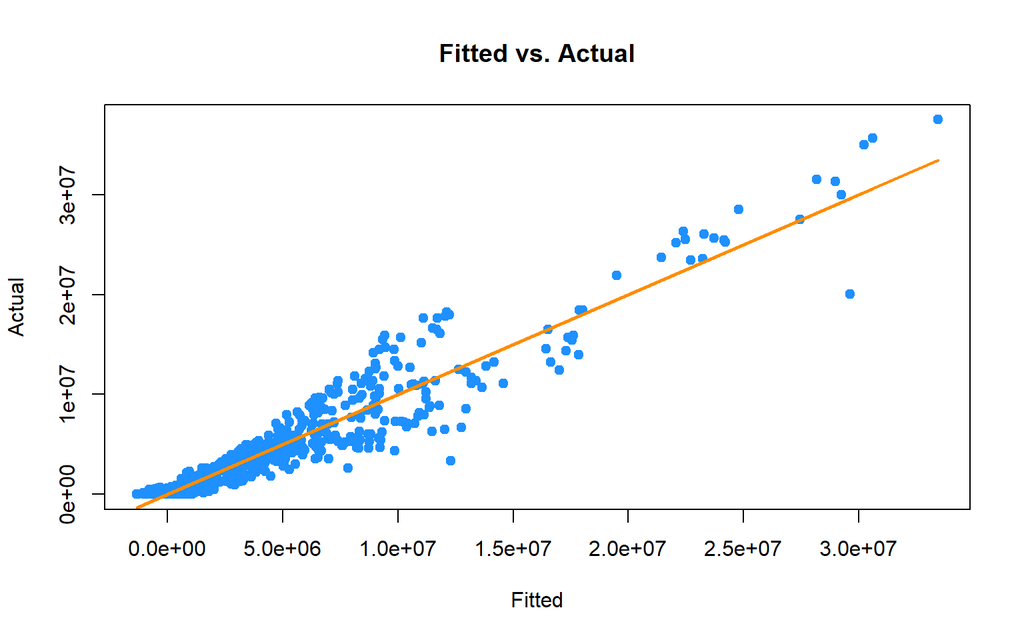

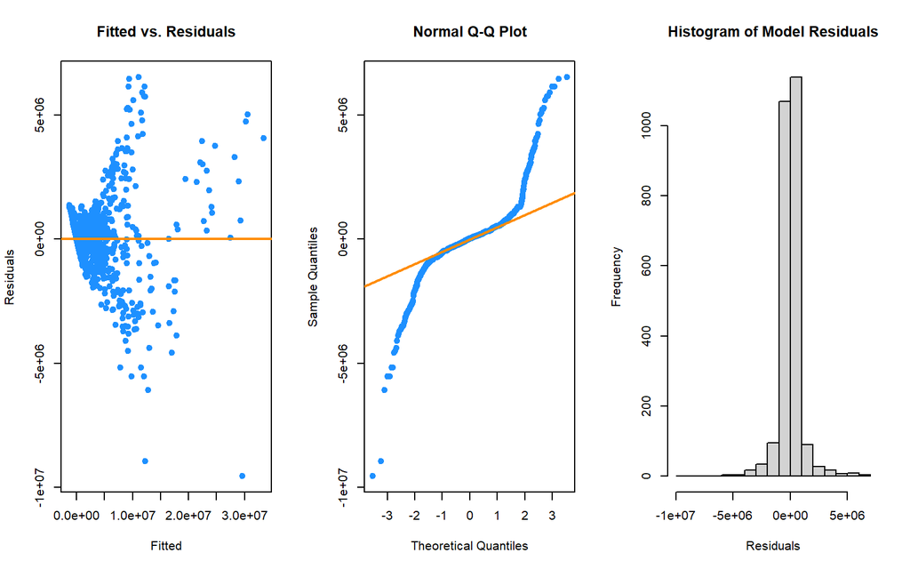

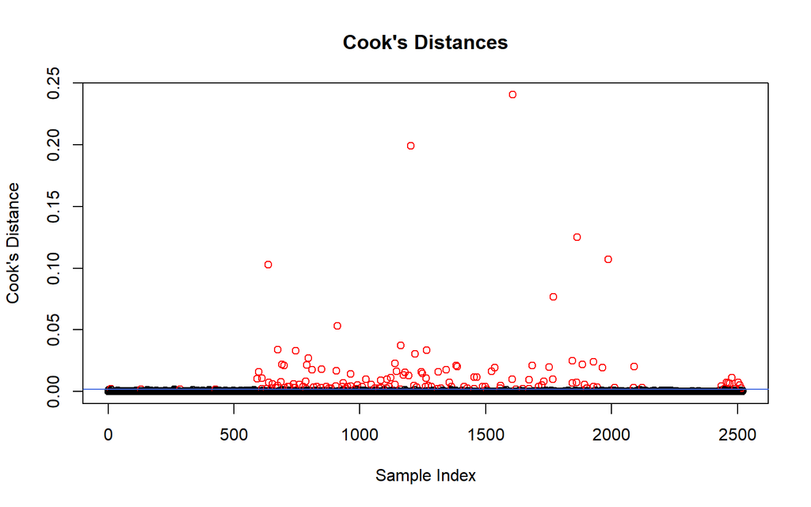

```
## [1] "LOOCV-RMSE:"      "1010377.94191328"
```

```
##                      GVIF Df GVIF^(1/(2*Df))
## Crop             3.117784  4        1.152738
## Season           3.539887  5        1.134747
## Zone             3.413731  5        1.130636
## Area            27.194007  1        5.214787
## Annual_Rainfall  1.899449  1        1.378205
## Fertilizer      25.738502  1        5.073313
## Pesticide       14.771989  1        3.843435
```

```r
baseline.cropyear_omit <- lm(I(Production) ~ ., data = crops.train.no_infl)

bc <- boxcox(baseline.cropyear_omit)
```

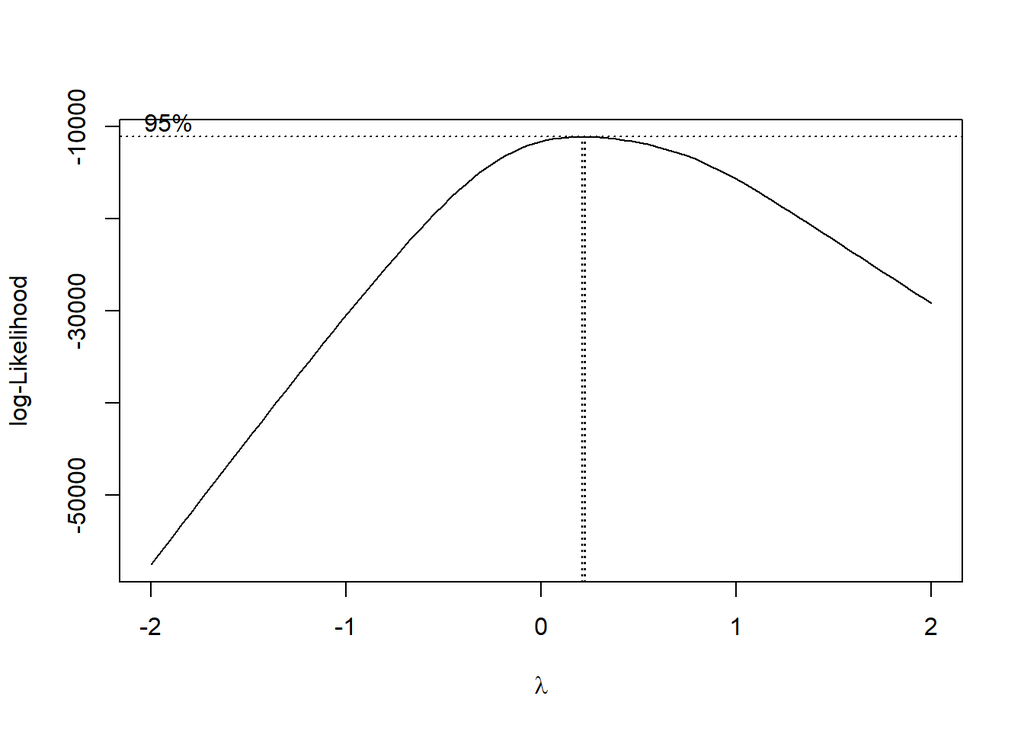

```r
(baseline.bc.cropyear_omit_lambda <- bc$x[which.max(bc$y)])
```

```
## [1] 0.2222222
```

```r
baseline.bc.cropyear_omit <- lm(bc_transform(Production, baseline.bc.cropyear_omit_lambda) ~ ., data = crops.train.no_infl)
output_diagnostics(baseline.bc.cropyear_omit)
```

```
## [1] "Model Summary:"
##
## Call:
## lm(formula = bc_transform(Production, baseline.bc.cropyear_omit_lambda) ~
##     ., data = crops.train.no_infl)
##
## Residuals:
##     Min      1Q  Median      3Q     Max
## -95.643 -13.490   0.985  14.798  51.764
##
## Coefficients:
##                     Estimate Std. Error t value Pr(>|t|)
## (Intercept)        4.668e+01  3.050e+00  15.305  < 2e-16 ***
## CropMaize          2.066e+01  1.826e+00  11.315  < 2e-16 ***
## CropOther Cereals -1.439e+01  2.533e+00  -5.682 1.49e-08 ***
## CropRice           3.372e+01  1.947e+00  17.325  < 2e-16 ***
## CropWheat          2.058e+01  1.828e+00  11.253  < 2e-16 ***
## SeasonKharif       5.510e+00  1.977e+00   2.787  0.00537 **
## SeasonRabi         1.945e+00  2.127e+00   0.915  0.36053
## SeasonSummer      -8.716e+00  2.078e+00  -4.194 2.83e-05 ***
## SeasonWhole Year  -1.473e+01  4.775e+00  -3.084  0.00207 **
## SeasonWinter       8.293e-01  2.475e+00   0.335  0.73764
## ZoneNorth Eastern -1.894e+01  1.540e+00 -12.299  < 2e-16 ***
## ZoneEastern        1.380e-01  1.587e+00   0.087  0.93070
## ZoneCentral       -1.198e+01  1.609e+00  -7.450 1.28e-13 ***
## ZoneNorthern      -7.276e+00  1.661e+00  -4.381 1.23e-05 ***
## ZoneWestern       -2.227e-01  1.699e+00  -0.131  0.89571
## Area               1.492e-05  1.755e-06   8.501  < 2e-16 ***
## Annual_Rainfall   -5.969e-03  6.886e-04  -8.667  < 2e-16 ***
## Fertilizer         4.112e-08  1.252e-08   3.284  0.00104 **
## Pesticide          5.641e-06  4.626e-06   1.219  0.22279
## ---
## Signif. codes:  0 '***' 0.001 '**' 0.01 '*' 0.05 '.' 0.1 ' ' 1
##
## Residual standard error: 21.24 on 2502 degrees of freedom
## Multiple R-squared:   0.74,  Adjusted R-squared:  0.7381
## F-statistic: 395.6 on 18 and 2502 DF,  p-value: < 2.2e-16
```

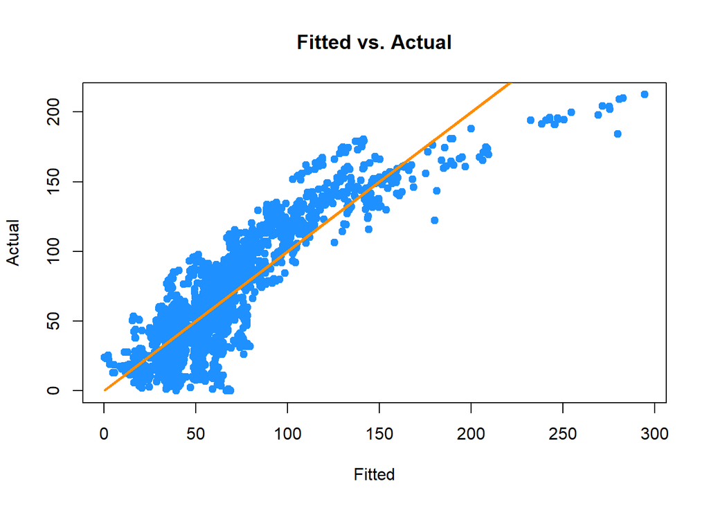

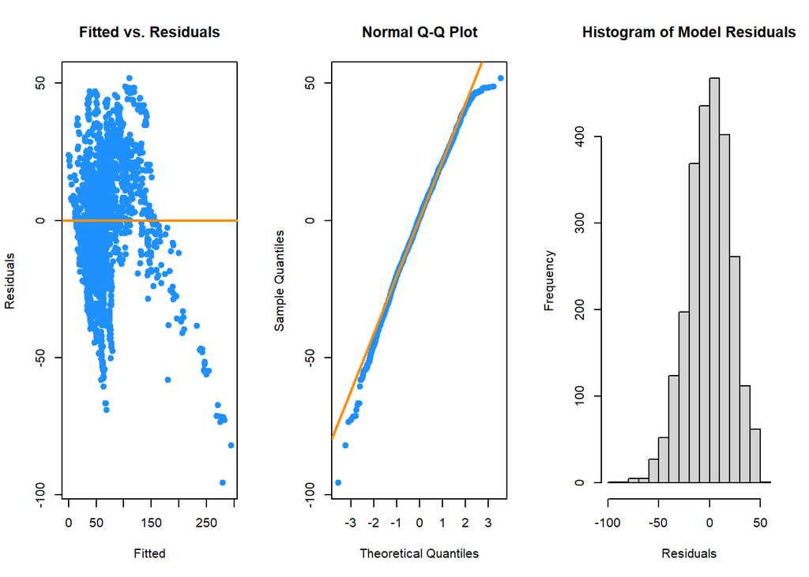

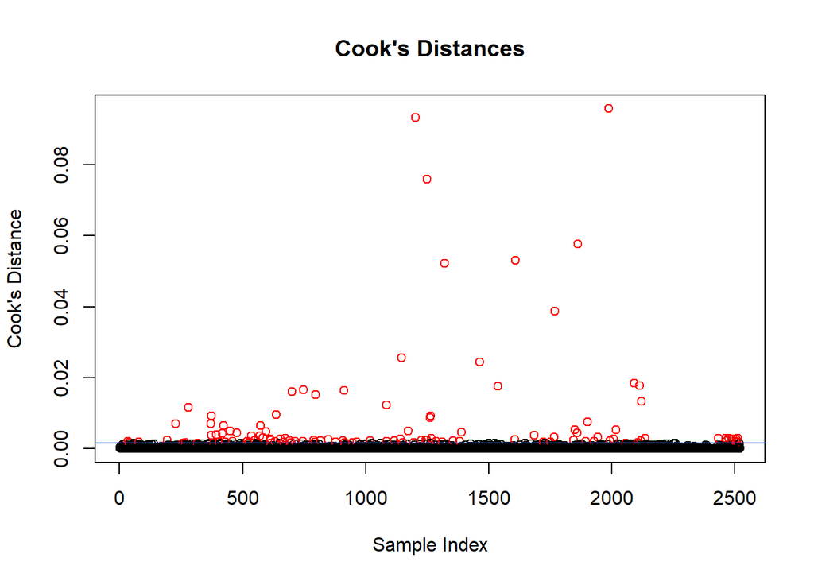

```
## [1] "LOOCV-RMSE:"      "21.4104338016814"
```

```
##                      GVIF Df GVIF^(1/(2*Df))
## Crop             3.117784  4        1.152738
## Season           3.539887  5        1.134747
## Zone             3.413731  5        1.130636
## Area            27.194007  1        5.214787
## Annual_Rainfall  1.899449  1        1.378205
## Fertilizer      25.738502  1        5.073313
## Pesticide       14.771989  1        3.843435
```

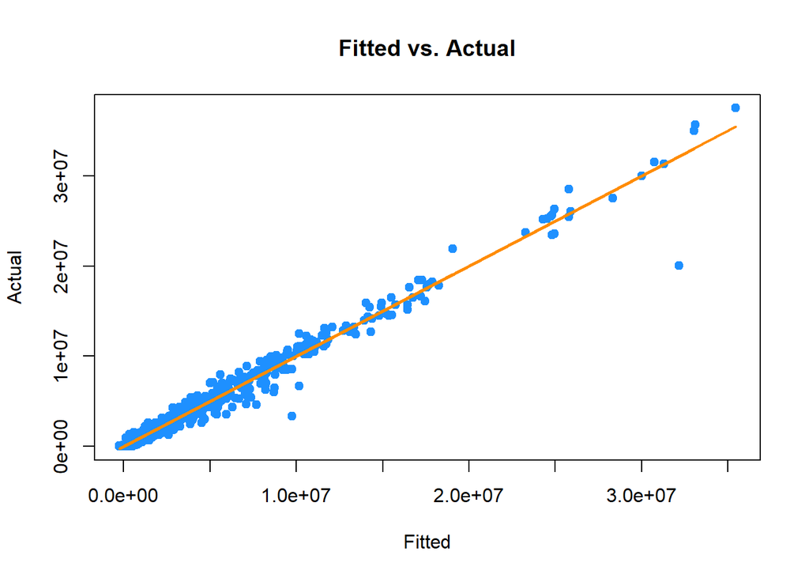

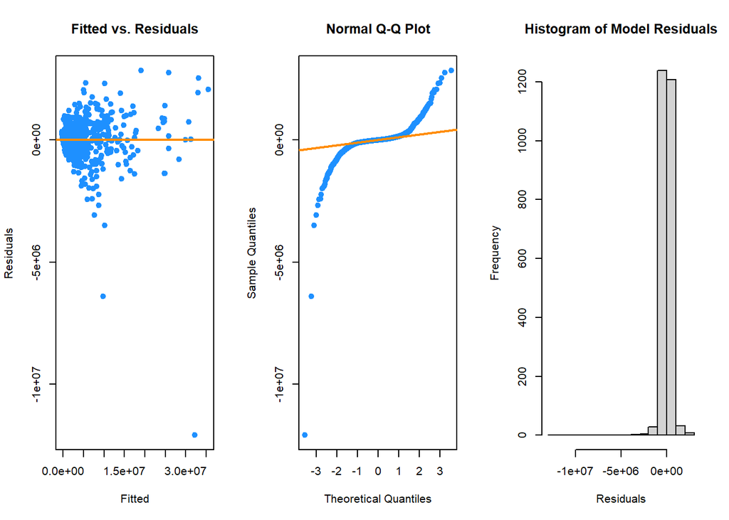

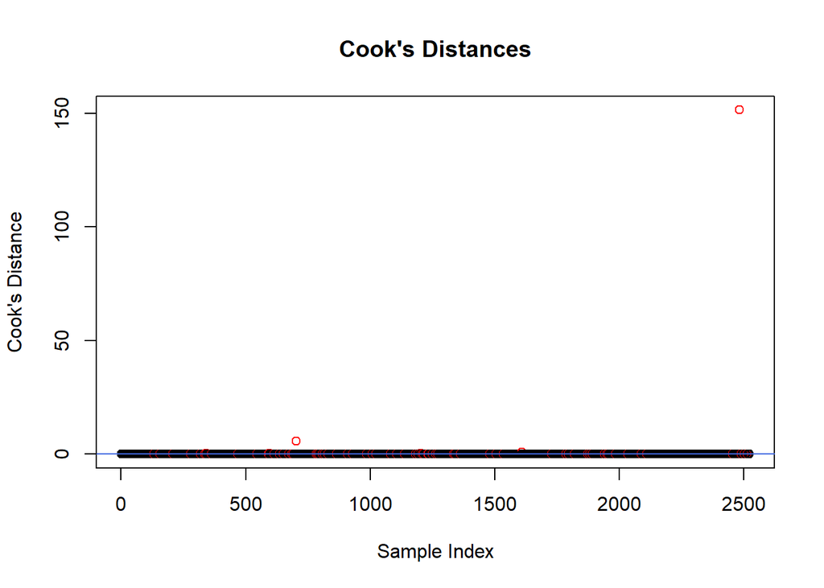

```
## [1] "LOOCV-RMSE:"      "1464612.88969158"
```

```r
# continuous-categorical interactions
baseline.poly.form.cropyear_omit <- as.formula(Production ~
  (poly(Area, degree = 2, raw = 1) +
    poly(Annual_Rainfall, degree = 2, raw = 1) +
    poly(Fertilizer, degree = 2, raw = 1) +
    poly(Pesticide, degree = 2, raw = 1)) *
    (Crop + Season + Zone))
baseline.poly.cropyear_omit <- lm(baseline.poly.form.cropyear_omit, data = crops.train)
output_diagnostics(baseline.poly.cropyear_omit, vif = 0)
```

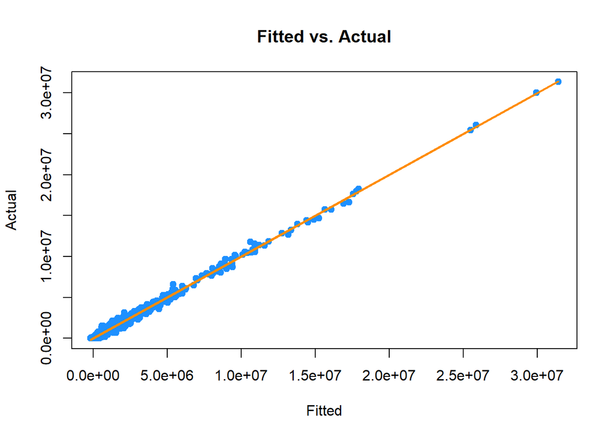

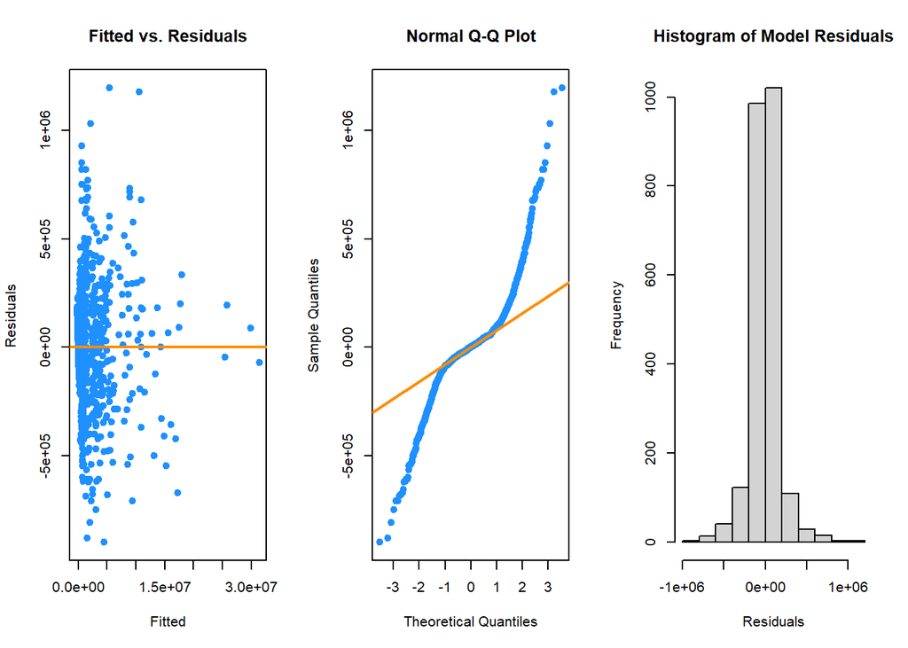

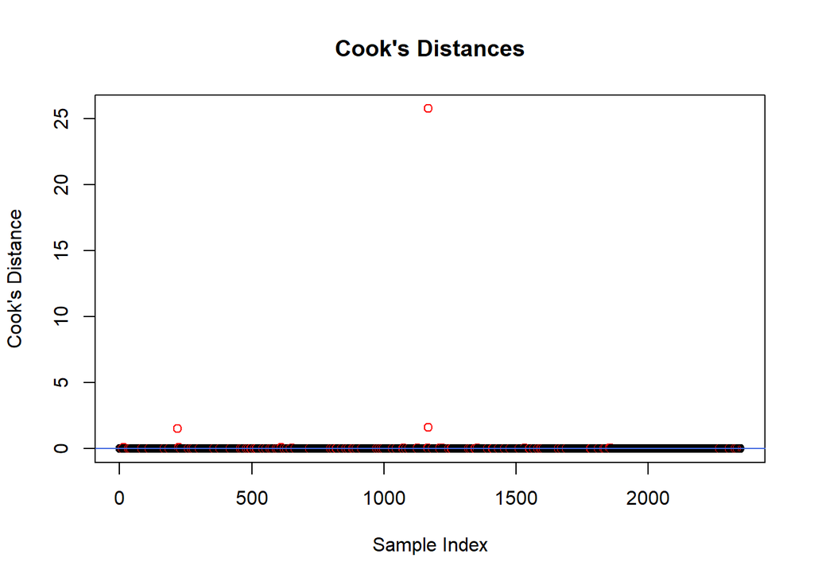

```
## [1] "LOOCV-RMSE:"      "298425.824852532"
```

```r
crops.train.poly.no_infl <- crops.train[!idx_infl_pts(baseline.poly.cropyear_omit), ]

baseline.poly.cropyear_omit <- lm(baseline.poly.form.cropyear_omit, data = crops.train.poly.no_infl)
output_diagnostics(baseline.poly.cropyear_omit, vif = 0)
```

```r
bc <- boxcox(baseline.poly.cropyear_omit)
```

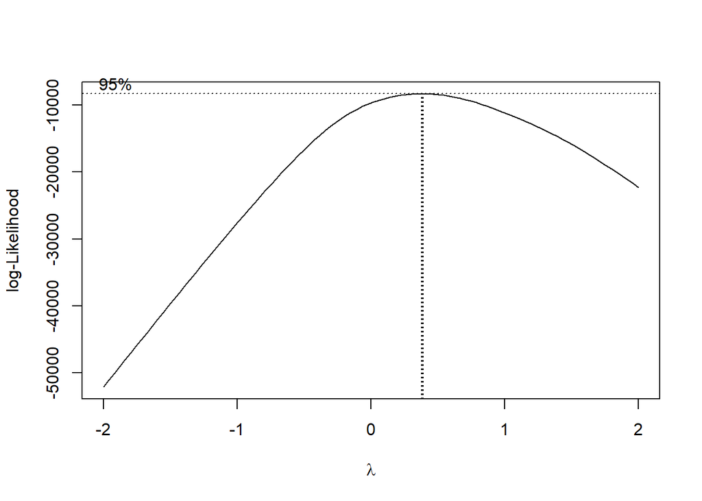

```r
(baseline.poly.bc.cropyear_omit_lambda <- bc$x[which.max(bc$y)])
```

```
## [1] 0.3838384
```

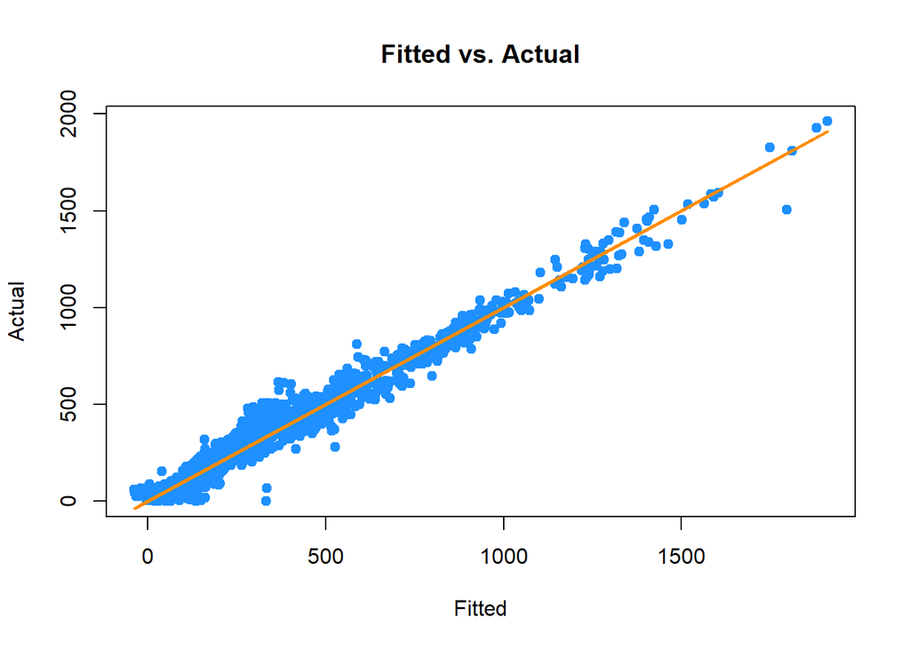

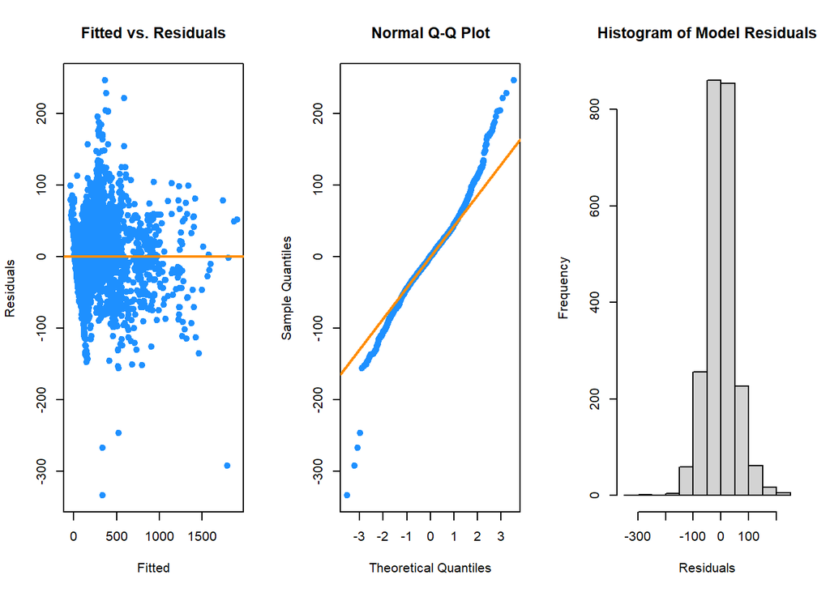

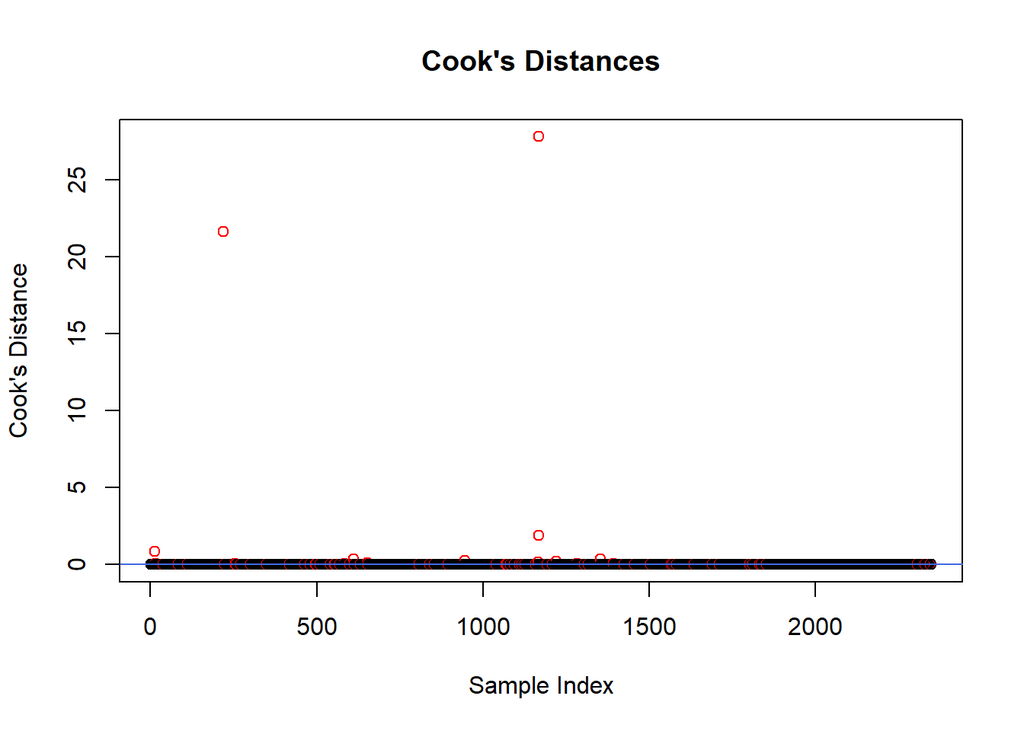

```
## [1] "LOOCV-RMSE:"      "110.329829715262"
```

```r
baseline.poly.bc.cropyear_omit <- lm(
  paste(
    "bc_transform(Production, baseline.poly.bc.cropyear_omit_lambda) ~ ",
    paste(
      attr(terms(baseline.poly.form.cropyear_omit),
        which = "term.labels"
      ),
      collapse = " + "
    )
  ),
  data = crops.train.poly.no_infl
)
output_diagnostics(baseline.poly.bc.cropyear_omit, vif = 0)
```